# Homework 6

```r
library(bmstdr)
library(spBayes)   # used by Bspatial(package = "spBayes")
library(rstan)     # used by Bspatial(package = "stan")
library(coda)
library(ggplot2)

# Load wolfcamp data directly without loading geoR.dll
lazyLoad(file.path(find.package("geoR"), "data", "Rdata"))
```

```r
coords <- as.matrix(wolfcamp$coords)
z      <- as.numeric(wolfcamp$data)
n      <- length(z)

# Centre coordinates for better MCMC mixing of the linear trend
x0 <- mean(coords[, 1]); y0 <- mean(coords[, 2])
df <- data.frame(
  x   = coords[, 1],
  y   = coords[, 2],
  x_c = coords[, 1] - x0,
  y_c = coords[, 2] - y0,
  z   = z
)
D_mat <- as.matrix(dist(coords))
X_mat <- model.matrix(~ x_c + y_c, data = df)
set.seed(2026)
```

# Homework 6

Following Homework 1, the data exhibit a strong linear spatial trend and residual spatial dependence. The model is

$$Z(s) = \beta_0 + \beta_1 x_c(s) + \beta_2 y_c(s) + W(s) + \varepsilon(s),$$

where $x_c, y_c$ are the centred coordinates, $W(s)$ is a zero-mean Gaussian process with exponential covariance $\sigma^2 \exp(-h \phi)$ ($\phi = 1/\text{range}$) and $\varepsilon(s) \sim \mathcal{N}(0, \tau^2)$ is the nugget effect (not present in `package = "none"`).

The workflow is the same for the three methods:

1. fit the model, compare parameter estimates with the ML reference and **plot the posterior distributions of all parameters** for the three methods;
2. predict on a $20 \times 20$ grid and build pointwise 95 % posterior predictive intervals;
3. compare out of sample with 5-fold cross-validation (parameters re-estimated in every fold) and proper scoring rules (RMSE, CRPS, LogS, IS95, coverage and width).

# Part I: Bayesian estimation (none vs spBayes vs stan)

## 1.1 Functions and ML reference

```r
# ML fit (reference, exponential covariance with nugget)
fit_ml_exp <- function(z, X, D) {
  n <- length(z)
  maxd <- max(D)
  gls_ml <- function(range_val, nu) {
    R  <- chol(exp(-D / range_val) + diag(nu, n))
    Xs <- backsolve(R, X, transpose = TRUE)
    zs <- backsolve(R, z, transpose = TRUE)
    beta <- solve(crossprod(Xs), crossprod(Xs, zs))
    s2   <- sum((zs - Xs %*% beta)^2) / n
    list(logLik = -0.5 * (n * log(2 * pi) + 2 * sum(log(diag(R))) + n * log(s2) + n),
         beta = c(beta), sigma2 = s2)
  }
  nll <- function(p) {
    v <- tryCatch(-gls_ml(exp(p[1]), exp(p[2]))$logLik, error = function(e) 1e10)
    if (is.finite(v)) v else 1e10
  }
  o <- optim(log(c(0.3 * maxd, 0.2)), nll, method = "L-BFGS-B",
             lower = log(c(1, 1e-4)), upper = log(c(3 * maxd, 100)))
  r_hat <- exp(o$par[1]); nu_hat <- exp(o$par[2])
  g <- gls_ml(r_hat, nu_hat)
  list(beta = g$beta, sigma2 = g$sigma2, tau2 = nu_hat * g$sigma2, range = r_hat)
}

# Proper scores from posterior predictive draws (bmstdr: n_te x N matrix)
score_draws <- function(y, draws) {
  draws <- as.matrix(draws)
  if (nrow(draws) != length(y)) draws <- t(draws)
  pred  <- apply(draws, 1, median)
  lower <- apply(draws, 1, quantile, probs = 0.025)
  upper <- apply(draws, 1, quantile, probs = 0.975)
  width <- upper - lower
  is95  <- width + 40 * pmax(lower - y, 0) + 40 * pmax(y - upper, 0)
  # Empirical CRPS: E|X - y| - 0.5 E|X - X'|
  crps_vec <- sapply(seq_along(y), function(i) {
    x <- sort(draws[i, ])
    m <- length(x)
    e1 <- mean(abs(x - y[i]))
    e2 <- sum((2 * seq_len(m) - m - 1) * x) / (m^2)
    e1 - e2
  })
  # Normal approximation to the predictive density for LogS
  mu_d <- rowMeans(draws)
  sd_d <- apply(draws, 1, sd)
  logs_vec <- -dnorm(y, mean = mu_d, sd = sd_d, log = TRUE)
  data.frame(
    y = y, pred = pred, lower = lower, upper = upper,
    CRPS = crps_vec, LogS = logs_vec, IS95 = is95,
    covered = (y >= lower & y <= upper), width = width
  )
}

ci_str <- function(v) sprintf("%.1f [%.1f, %.1f]", median(v), quantile(v, 0.025), quantile(v, 0.975))

ml_fit <- fit_ml_exp(z, X_mat, D_mat)
```

## 1.2 Fitting the three methods with `Bspatial()`

All three fits use the same mean structure and, whenever the method allows it, the same priors: flat-like prior on $\beta$ (bmstdr default, very large prior variance), $\sigma^2 \sim \text{IG}(2, 20000)$, $\tau^2 \sim \text{IG}(2, 5000)$ and $\phi = 1/\text{range} \sim \text{Uniform}(1/300, 1/5)$.

The arguments describing the prior on $\phi$ are gathered in `phi_prior` so that they can be adapted in one place (see `?Bspatial` for the exact argument names of the installed version).

```r
N_mcmc <- 6000   # total iterations (spBayes and stan)
burn   <- 2000   # burn-in / warm-up

phi_prior <- list(prior.phi = "Unif", prior.phi.param = c(1 / 300, 1 / 5))

# One wrapper so that the three methods are called in exactly the same way
fit_bm <- function(pkg, data, validrows = NULL, phi_fixed = NULL) {
  a <- list(package = pkg, model = "spat", formula = z ~ x_c + y_c, data = data,
            coordtype = "plain", coords = 1:2, validrows = validrows,
            prior.sigma2 = c(2, 20000),
            mchoice = FALSE, plotit = FALSE, verbose = FALSE)
  if (pkg == "none") {
    a$phi <- phi_fixed
    a$N   <- 2000
  } else {
    a <- c(a, list(prior.tau2 = c(2, 5000), N = N_mcmc, burn.in = burn), phi_prior)
    if (pkg == "stan") { a$no.chains <- 3; a$phi <- phi_fixed }
  }
  do.call(Bspatial, a)
}

pkgs <- c(none = "none", spBayes = "spBayes", stan = "stan")
fits <- list(); times <- numeric(0)
for (m in names(pkgs)) {
  times[m] <- system.time(
    fits[[m]] <- fit_bm(pkgs[[m]], df, phi_fixed = 1 / ml_fit$range)
  )[["elapsed"]]
}
```

## 1.3 Extracting the posterior samples

`Bspatial(package = "none")` only returns posterior summaries, so for this method we draw from the exact conjugate posterior (normal–inverse-gamma with $\phi$ fixed). The result is checked against the summaries returned by bmstdr in the table below. For `spBayes` and `stan` the samples are taken from the underlying fitted objects.

```r
# Exact posterior draws for package = "none" (phi fixed, no nugget, flat prior on beta)
rpost_none <- function(d, phi, a = 2, b = 20000, S = 4000) {
  X <- model.matrix(~ x_c + y_c, d); y <- d$z; nn <- length(y); p <- ncol(X)
  R  <- exp(-phi * as.matrix(dist(d[, c("x", "y")])))
  Ch <- chol(R)
  Xs <- backsolve(Ch, X, transpose = TRUE); ys <- backsolve(Ch, y, transpose = TRUE)
  Vb <- solve(crossprod(Xs)); bh <- as.vector(Vb %*% crossprod(Xs, ys))
  ss <- sum((ys - Xs %*% bh)^2)
  sig2 <- 1 / rgamma(S, a + (nn - p) / 2, b + ss / 2)
  L <- chol(Vb)
  B <- t(sapply(sig2, function(s) bh + sqrt(s) * as.vector(t(L) %*% rnorm(p))))
  data.frame(beta0 = B[, 1], beta1 = B[, 2], beta2 = B[, 3],
             sigma2 = sig2, tau2 = NA_real_, range = 1 / phi)
}

post_draws <- function(fit, pkg) {
  if (pkg == "none") return(rpost_none(df, 1 / ml_fit$range))
  if (pkg == "spBayes") {
    obj <- fit$fit
    if (is.null(obj$p.beta.recover.samples))
      obj <- spRecover(obj, start = burn + 1, thin = 5, get.w = FALSE, verbose = FALSE)
    B  <- as.matrix(obj$p.beta.recover.samples)
    th <- as.matrix(obj$p.theta.recover.samples)
    return(data.frame(beta0 = B[, 1], beta1 = B[, 2], beta2 = B[, 3],
                      sigma2 = th[, "sigma.sq"], tau2 = th[, "tau.sq"],
                      range = 1 / th[, "phi"]))
  }
  if (pkg == "stan") {
    m <- as.matrix(fit$fit)   # all chains stacked, warm-up already removed
    pick <- function(pat) {
      j <- grep(pat, colnames(m))
      if (!length(j)) stop("Stan parameter not found: ", pat,
                           "\nAvailable: ", paste(colnames(m), collapse = ", "))
      m[, j[1]]
    }
    b <- m[, grep("^beta", colnames(m))[1:3]]
    return(data.frame(beta0 = b[, 1], beta1 = b[, 2], beta2 = b[, 3],
                      sigma2 = pick("^sigma"), tau2 = pick("^tau"),
                      range = ml_fit$range))
  }
}

post <- lapply(names(pkgs), function(m) post_draws(fits[[m]], pkgs[[m]]))
names(post) <- names(pkgs)
```

## 1.4 Parameter comparison and MCMC diagnostics

```r
params <- c("beta0", "beta1", "beta2", "sigma2", "tau2", "range")
ml_vec <- c(ml_fit$beta, ml_fit$sigma2, ml_fit$tau2, ml_fit$range)

summ <- function(m) {
  d <- post[[m]]
  sapply(params, function(p) {
    v <- d[[p]]
    if (all(is.na(v))) "no nugget"
    else if (sd(v) == 0) sprintf("%.1f (fixed)", v[1])
    else ci_str(v)
  })
}
ess <- function(m) {
  d <- post[[m]]
  sapply(params, function(p) {
    v <- d[[p]]
    if (all(is.na(v)) || sd(v) == 0) NA else round(effectiveSize(mcmc(v)))
  })
}

diag_tab <- data.frame(
  Parameter = params,
  ML = round(ml_vec, 2),
  `none: median [95% CI]`    = summ("none"),
  `spBayes: median [95% CI]` = summ("spBayes"),
  `stan: median [95% CI]`    = summ("stan"),
  `ESS none`    = ess("none"),
  `ESS spBayes` = ess("spBayes"),
  `ESS stan`    = ess("stan"),
  check.names = FALSE
)
knitr::kable(diag_tab, row.names = FALSE,
  caption = sprintf("Parameter estimates and effective sample sizes (runtime: none = %.2f s, spBayes = %.1f s, stan = %.1f s).",
                    times["none"], times["spBayes"], times["stan"]))
```

Parameter estimates and effective sample sizes (runtime: none = 0.01 s, spBayes = 1.0 s, stan = 745.2 s).

| Parameter | ML | none: median [95% CI] | spBayes: median [95% CI] | stan: median [95% CI] | ESS none | ESS spBayes | ESS stan |
| --- | --- | --- | --- | --- | --- | --- | --- |
| beta0 | 623.70 | 627.7 [588.9, 668.5] | 357.5 [185.0, 533.9] | 621.8 [589.8, 655.3] | 4584 | 182 | 584 |
| beta1 | -1.31 | -1.3 [-1.6, -1.0] | -1.5 [-2.2, -0.8] | -1.3 [-1.6, -1.1] | 4000 | 800 | 969 |
| beta2 | -1.21 | -1.2 [-1.6, -0.8] | -1.0 [-1.8, -0.2] | -1.2 [-1.6, -0.9] | 4000 | 800 | 715 |
| sigma2 | 3715.82 | 6438.0 [4869.1, 8858.8] | 18079.4 [7325.1, 32462.7] | 3999.9 [2570.8, 6233.5] | 4000 | 246 | 4077 |
| tau2 | 624.16 | no nugget | 1140.0 [645.1, 1971.0] | 1014.1 [552.3, 1865.2] | NA | 453 | 2762 |
| range | 34.12 | 34.1 (fixed) | 264.7 [144.6, 298.3] | 34.1 (fixed) | NA | 72 | NA |

Check of my exact draws for `package = "none"` against the summaries returned by bmstdr (posterior means):

```r
bm_p <- fits$none$params
chk <- data.frame(
  Parameter = rownames(bm_p)[1:4],
  `bmstdr (Bspatial)` = round(bm_p[1:4, 1], 2),
  `exact draws (here)` = round(c(colMeans(post$none[, c("beta0", "beta1", "beta2", "sigma2")])), 2),
  check.names = FALSE
)
knitr::kable(chk, row.names = FALSE)
```

| Parameter | bmstdr (Bspatial) | exact draws (here) |
| --- | --- | --- |
| (Intercept) | 627.38 | 627.63 |
| x_c | -1.31 | -1.31 |
| y_c | -1.21 | -1.22 |
| sigma2 | 6351.79 | 6553.01 |

If the two columns differ noticeably, the prior parametrisation of `prior.sigma2` or `prior.M` in the installed bmstdr version differs from the one assumed in `rpost_none()` and the latter should be adjusted.

## 1.5 Posterior distributions of the parameters

The figures overlay the posterior densities of the three methods. The dashed grey line is the prior density (when it is proper), and a dotted vertical line is used when a parameter is fixed (the range in `none`).

```r
long <- do.call(rbind, lapply(names(post), function(m)
  data.frame(Method = m, Parameter = rep(params, each = nrow(post[[m]])),
             value = unlist(post[[m]][params], use.names = FALSE))))
long <- long[!is.na(long$value), ]
long$Parameter <- factor(long$Parameter, levels = params)
long$Method    <- factor(long$Method, levels = names(pkgs))

# parameters that are constant for a given method -> vertical line, not a density
const <- aggregate(value ~ Method + Parameter, long, function(v) sd(v) == 0)
names(const)[3] <- "const"
long  <- merge(long, const)
fixed <- unique(long[long$const, c("Method", "Parameter", "value")])
long  <- long[!long$const, ]

# prior densities
dig <- function(x, a, b) b^a / gamma(a) * x^(-a - 1) * exp(-b / x)
prior_curve <- function(par) {
  v  <- long$value[long$Parameter == par]
  xs <- seq(quantile(v, 0.001), quantile(v, 0.999), length.out = 400)
  y <- switch(par,
    sigma2 = dig(xs, 2, 20000),
    tau2   = dig(xs, 2, 5000),
    range  = (1 / (1 / 5 - 1 / 300)) / xs^2 * (xs >= 5 & xs <= 300))
  data.frame(Parameter = factor(par, levels = params), x = xs, y = y)
}
priors_df <- do.call(rbind, lapply(c("sigma2", "tau2", "range"), prior_curve))

plot_post <- function(pars, logx = FALSE) {
  p <- ggplot(subset(long, Parameter %in% pars), aes(value, colour = Method)) +
    geom_density(linewidth = 0.8, adjust = 1.2) +
    geom_line(data = subset(priors_df, Parameter %in% pars), aes(x, y),
              inherit.aes = FALSE, colour = "grey40", linetype = 2) +
    geom_vline(data = subset(fixed, Parameter %in% pars),
               aes(xintercept = value, colour = Method), linetype = 3, linewidth = 0.8) +
    facet_wrap(~ Parameter, scales = "free") +
    labs(x = NULL, y = "Posterior density") +
    theme_minimal()
  if (logx) p <- p + scale_x_log10()
  p
}
```

**Trend parameters** ($\beta_0, \beta_1, \beta_2$):

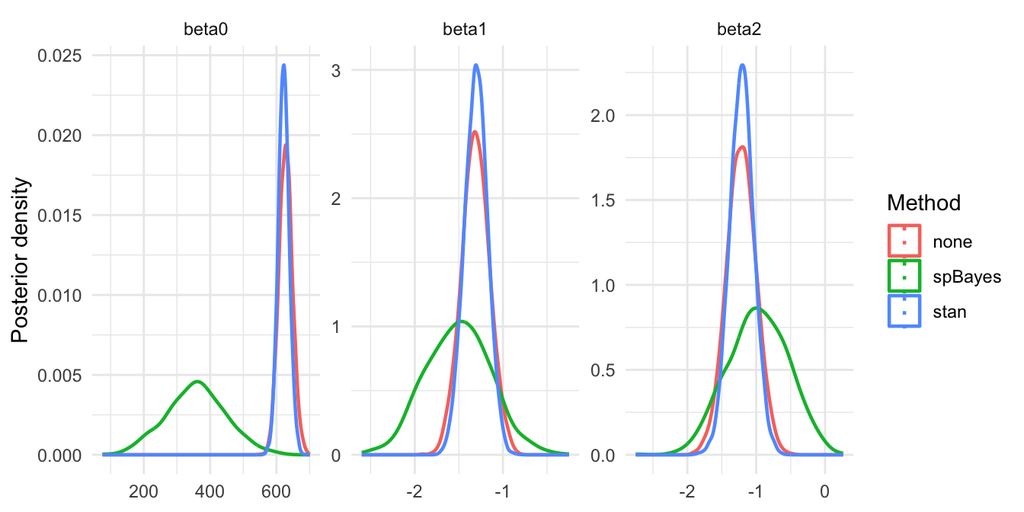

Figure 1

```r
plot_post(c("beta0", "beta1", "beta2"))
```

**Covariance parameters** ($\sigma^2$ and $\tau^2$):

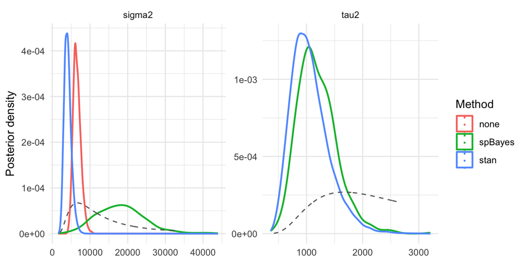

Figure 2

```r
plot_post(c("sigma2", "tau2"))
```

**Range** (log scale; the prior is $1/\text{range} \sim \text{U}(1/300, 1/5)$):

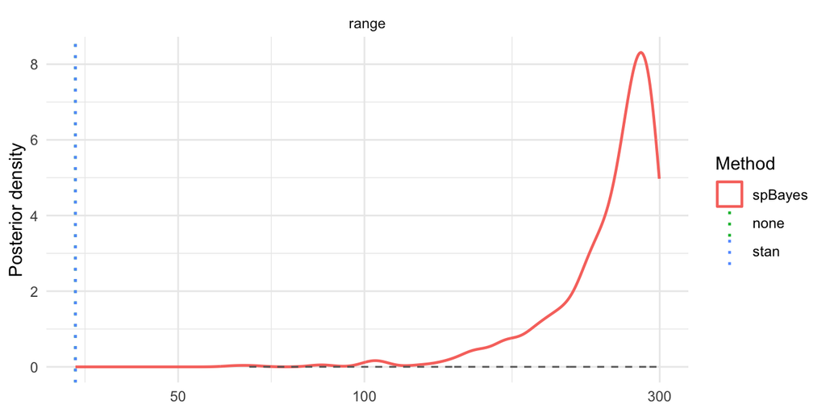

Figure 3

```r
plot_post("range", logx = TRUE)
```

Trace plots of the sampled covariance parameters (for `stan`, the three chains are stacked one after the other):

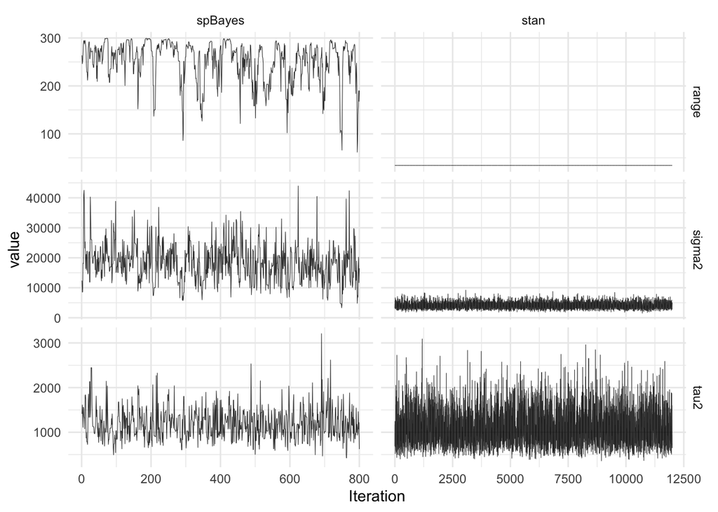

Figure 4

```r
tr <- do.call(rbind, lapply(c("spBayes", "stan"), function(m)
  do.call(rbind, lapply(c("sigma2", "tau2", "range"), function(p)
    data.frame(Method = m, Parameter = p, Iteration = seq_len(nrow(post[[m]])),
               value = post[[m]][[p]])))))
ggplot(tr, aes(Iteration, value)) +
  geom_line(linewidth = 0.2, alpha = 0.8) +
  facet_grid(Parameter ~ Method, scales = "free") +
  theme_minimal()
```

# Part II: Posterior predictive intervals on a $20 \times 20$ grid

We construct the $20 \times 20$ grid covering the Wolfcamp domain (as in Homework 1) and compute the pointwise predictive median and 95 % posterior predictive intervals for the three methods, all obtained from `valpreds` (posterior predictive draws of a new observation).

```r
ngrid <- 20
gx <- seq(min(df$x), max(df$x), length.out = ngrid)
gy <- seq(min(df$y), max(df$y), length.out = ngrid)
grid_df <- expand.grid(x = gx, y = gy)
grid_df$x_c <- grid_df$x - x0
grid_df$y_c <- grid_df$y - y0
grid_df$z   <- mean(z)   # placeholder for validrows (not used in fitting)
df_all <- rbind(df, grid_df)

grid_pred <- lapply(names(pkgs), function(m) {
  f <- fit_bm(pkgs[[m]], df_all, validrows = (n + 1):nrow(df_all),
              phi_fixed = 1 / ml_fit$range)
  d <- as.matrix(f$valpreds)
  if (nrow(d) != nrow(grid_df)) d <- t(d)
  data.frame(Method = m, x = grid_df$x, y = grid_df$y,
             lower  = apply(d, 1, quantile, probs = 0.025),
             median = apply(d, 1, median),
             upper  = apply(d, 1, quantile, probs = 0.975))
})
g_all <- do.call(rbind, grid_pred)
g_all$width  <- g_all$upper - g_all$lower
g_all$Method <- factor(g_all$Method, levels = names(pkgs))
```

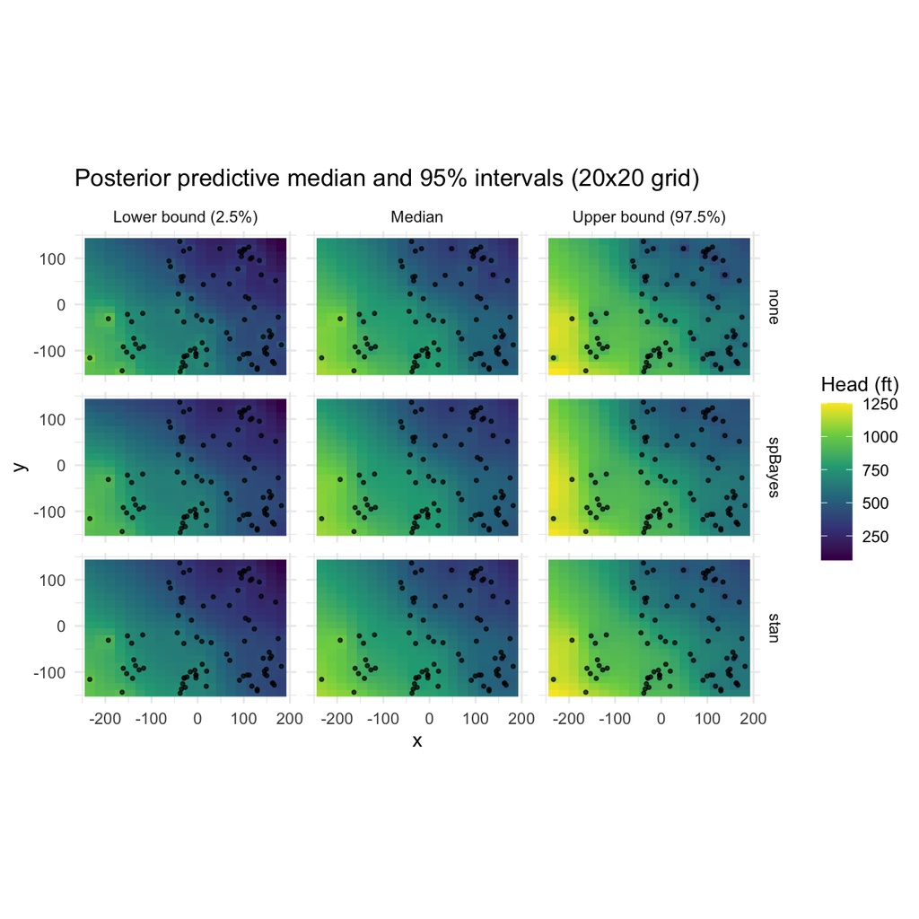

Figure 5

```r
mp <- rbind(
  data.frame(g_all[, c("Method", "x", "y")], value = g_all$lower,  what = "Lower bound (2.5%)"),
  data.frame(g_all[, c("Method", "x", "y")], value = g_all$median, what = "Median"),
  data.frame(g_all[, c("Method", "x", "y")], value = g_all$upper,  what = "Upper bound (97.5%)")
)
mp$what <- factor(mp$what, levels = c("Lower bound (2.5%)", "Median", "Upper bound (97.5%)"))

ggplot(mp, aes(x, y, fill = value)) +
  geom_raster() +
  geom_point(data = df, aes(x, y), inherit.aes = FALSE, size = 0.7, alpha = 0.7) +
  facet_grid(Method ~ what) +
  coord_equal() +
  scale_fill_viridis_c(name = "Head (ft)") +
  labs(title = "Posterior predictive median and 95% intervals (20x20 grid)") +
  theme_minimal()
```

Width of the 95 % predictive interval over the grid:

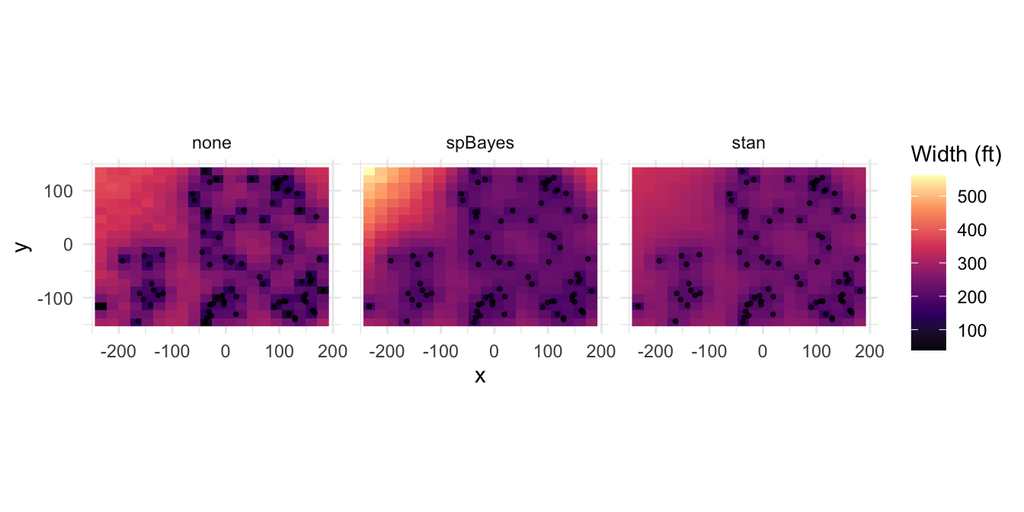

Figure 6

```r
ggplot(g_all, aes(x, y, fill = width)) +
  geom_raster() +
  geom_point(data = df, aes(x, y), inherit.aes = FALSE, size = 0.7, alpha = 0.7) +
  facet_wrap(~ Method) +
  coord_equal() +
  scale_fill_viridis_c(name = "Width (ft)", option = "magma") +
  theme_minimal()
```

```r
med <- sapply(grid_pred, function(a) a$median); colnames(med) <- names(pkgs)
wid <- tapply(g_all$width, g_all$Method, mean)
pairs <- combn(names(pkgs), 2, simplify = FALSE)
comp_grid <- data.frame(
  Pair = sapply(pairs, paste, collapse = " vs "),
  `Correlation of medians` = sapply(pairs, function(p) cor(med[, p[1]], med[, p[2]])),
  `Max abs. diff. of medians (ft)` = sapply(pairs, function(p) max(abs(med[, p[1]] - med[, p[2]]))),
  `Mean width, 1st method (ft)` = sapply(pairs, function(p) wid[[p[1]]]),
  `Mean width, 2nd method (ft)` = sapply(pairs, function(p) wid[[p[2]]]),
  check.names = FALSE
)
knitr::kable(comp_grid, digits = 3, row.names = FALSE,
             caption = "Agreement between the three methods on the 20x20 grid.")
```

Agreement between the three methods on the 20x20 grid.

| Pair | Correlation of medians | Max abs. diff. of medians (ft) | Mean width, 1st method (ft) | Mean width, 2nd method (ft) |
| --- | --- | --- | --- | --- |
| none vs spBayes | 0.998 | 53.188 | 253.027 | 254.503 |
| none vs stan | 0.999 | 36.192 | 253.027 | 249.141 |
| spBayes vs stan | 0.998 | 53.845 | 254.503 | 249.141 |